# Your project title

### Model Diagnostics

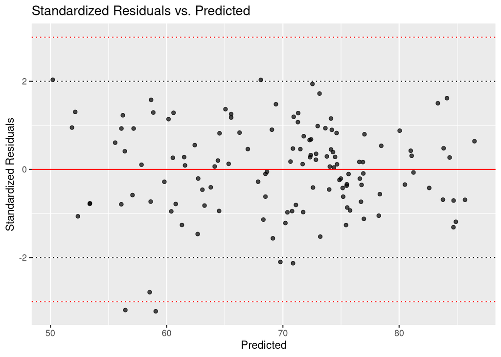

There are a few moderate outliers and two severe outliers. Will look into these later.

Leverage Threshold

| x |
| --- |
| 0.3230769 |

| obs_num | .hat |
| --- | --- |
| 3 | 0.3454304 |
| 25 | 1.0000000 |
| 40 | 0.3351759 |
| 43 | 0.3282685 |
| 54 | 0.7560570 |
| 55 | 0.4102857 |
| 65 | 0.3391883 |
| 69 | 0.3457028 |
| 82 | 0.3481338 |
| 84 | 0.3390330 |

[output cut: 5 more lines]

| obs_num | .cooksd |
| --- | --- |

The points in the first table are points with high leverage (.hat > leverage_threshold = 0.3230769) while the points in the second table are influential points (.cooksd > 0.5). 15 observations have high leverage and 0 observations are influential.

| names | x |
| --- | --- |
| RegionBALTICS | 1.408 |
| RegionC.W. OF IND. STATES | 1.899 |
| RegionEASTERN EUROPE | 1.920 |
| RegionLATIN AMER. & CARIB | 2.742 |
| RegionNEAR EAST | 1.721 |
| RegionNORTHERN AFRICA | 1.260 |
| RegionNORTHERN AMERICA | 1.441 |
| RegionOCEANIA | 1.630 |
| RegionSUB-SAHARAN AFRICA | 4.657 |
| RegionWESTERN EUROPE | 3.002 |
| `Adult Mortality` | 2.254 |
| `infant deaths` | 244.366 |
| `Hepatitis B` | 2.972 |
| Measles | 3.156 |
| `under-five deaths` | 244.039 |
| `Total expenditure` | 1.328 |
| Diphtheria | 2.777 |
| `HIV/AIDS` | 2.016 |
| `Income composition of resources` | 13.166 |
| Schooling | 8.937 |

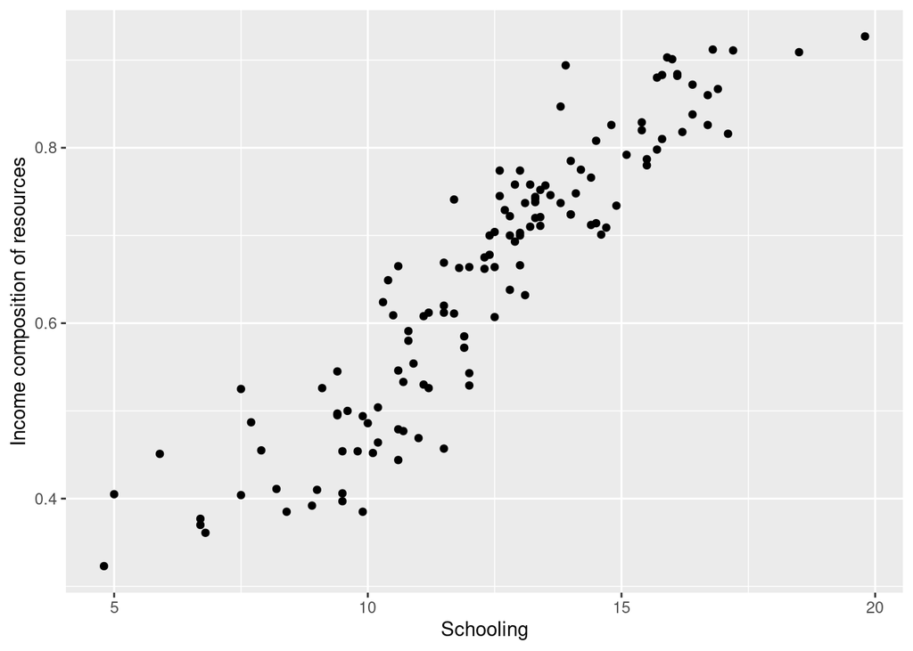

Variables with a VIF > 10 will have issues with multicollinearity. `infant deaths` and `under-five deaths` are clearly highly correlated (this makes a lot of sense in the context of the data). `Income composition of resources` appears to be correlated with `Schooling`.

We should try models without either `infant deaths` and `under-five deaths` and then use model comparison techniques to decide on which of these two variables should be removed.

| AIC | BIC | adj.r.squared |
| --- | --- | --- |
| 637.5806 | 697.7988 | 0.9162131 |

| AIC | BIC | adj.r.squared |
| --- | --- | --- |
| 637.343 | 697.5612 | 0.9163661 |

| AIC | BIC | adj.r.squared |
| --- | --- | --- |
| 695.5548 | 752.9054 | 0.8682948 |

| AIC | BIC | adj.r.squared |
| --- | --- | --- |
| 642.3352 | 699.6859 | 0.9125397 |

When comparing two models that are identical except that one includes `under-five deaths` and the other includes `infant deaths`, the one that includes `infant deaths` has lower values of AIC and BIC as well as a higher value of adjusted $R^2$. Likewise, given two models that have the same predictors except that one includes `Schooling` while the other includes `Income composition of resources`, the one that includes `Income composition of resources` is superior in terms of AIC, BIC, and adjusted $R^2$.

### Model Conditions/Assumptions

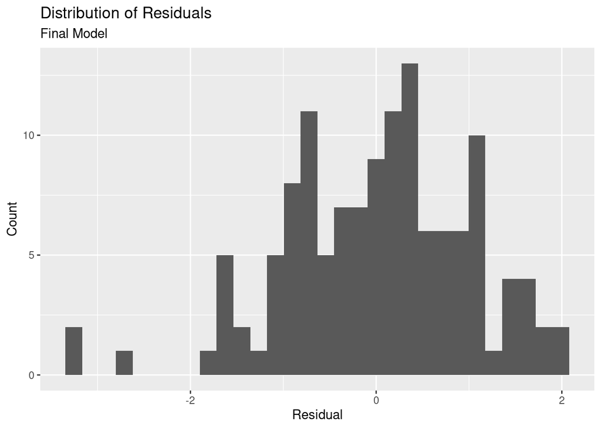

## Sources

[1] https://ourworldindata.org/life-expectancy

[2] https://europepmc.org/article/med/12785422/reload=0#impact

[3] https://www.kaggle.com/kumarajarshi/life-expectancy-who.

[4] https://www.kaggle.com/fernandol/countries-of-the-world